# CH3 决策树与分类算法--1

### 1. 决策树分类算法原理

#### 1.1 概述

决策树（decision tree）——是一种被广泛使用的分类算法。 决策树的优势在于构造过程不需要任何领域知识或参数设置。 在实际应用中，对于探测式的知识发现，决策树更加适用。

#### 1.2 算法思想

一个女孩的母亲要给这个女孩介绍男朋友，于是有了下面的对话：

```
  女儿：多大年纪了？      母亲：26。

  女儿：长的帅不帅？      母亲：挺帅的。

  女儿：收入高不？       母亲：不算很高，中等情况。

  女儿：是公务员不？      母亲：是，在税务局上班呢。

  女儿：那好，我去见见。
```

这个女孩的决策过程就是典型的分类树决策。

实质：通过年龄、长相、收入和是否公务员 把约会对象分为“见”和“不见”两个类别

可以用下图表示女孩的决策逻辑

[figure not shown]

```python
1. 绿色节点表示判断条件---非叶节点
2. 橙色节点表示决策结果---叶子节点
3. 箭头表示在一个判断条件在不同情况下的决策路径
图中红色箭头表示了上面例子中女孩的决策过程。
```

决策树：是一个树结构。其每个非叶节点表示一个特征属性上的测试，每个分支代表这个特征属性在某个值域上的输出，而每个叶节点存放一个类别。使用决策树进行决策的过程就是从根节点开始，测试待分类项中相应的特征属性，并按照其值选择输出分支，直到到达叶子节点，将叶子节点存放的类别作为决策结果。

假设现在有一批客户银行贷款逾期， 如表3-1 所示。

[figure not shown]

ID3决策树、C4.5决策树，以及CART决策树

各种决策树的主体思想大同小异，都主要涉及三要素，分别是特征选择、决策树的生成和决策树的剪枝.

### 1.3 特征选择

在实际建立决策树的过程中，每次特征选择时， 是有一套科学标准的， 这就是信息增益、信息增益比、基尼系数等。

### 1.3.1 信息增益

##### 1 熵

日常生活中，当我们要搞清楚某件事情时，这件事情的不确定性越大，我们需要了解的信息就越多。 由此可以看出， 一条信息的信息量大小和它的不确定性有直接关系。受此启发，人们就拿不确定性这个量来度量信息量的大小。

在信息论或概率统计中，用熵度量随机变量的不确定性。熵值越大，随机变量的不确定性就越大。

[figure not shown]

```python
#举例来说，如果有一个大小为10的布尔值样本集S_𝑏，其中有6个真值、4个假值，那么该布尔型样本分类的熵为：
𝐸𝑛𝑡𝑟𝑜𝑝𝑦(S_b)=-(6/10)𝑙𝑜𝑔(6/10)-(4/10)𝑙𝑜𝑔(4/10)    ##=0.9710
#(log为以2或者e为底的对数。np.log(x)---e为底)
```

```python
import numpy as np
def log(base,x):
    return np.log(x)/np.log(base)
E_S_b = -(6/10)*𝑙𝑜𝑔(2,6/10)-(4/10)*𝑙𝑜𝑔(2,4/10)
E_S_b
```

```
0.9709505944546686
```

[figure not shown]

#### 5 . 信患增益的计算实例

以上面银行贷款逾期例子中的数据为例，下面计算选择各个特征时产生的信息增益。

(1)首先，计算各个类别的熵。 样本标签一共包含"是"和"否"两类，其中， P(是) =3/8, P(否)=5/8，所以 H(Y)= -(3/8)log(3/8)-(5/8)log(5/8) = 0.9544

(2) 其次，计算各个特征(是否拥有房产，婚姻状况，年收入)对Y 的信息增 益。

对于房产特征:

一共有"是"和"否"两种， 两种出现的概率为P(是) =3/8, P(否)=5/8， 所以 由条件概率的性质有:

H(Y|房产)=(3/8)H(Y是) +(5/8)H(Y否) =(3/8)*0 +(5/8)[-(3/5)log(3/5)-(2/5)log(2/5)] = 0.6069

所以，如果采用有无房产特征来进行决策树划分，则产生的信息增益为

g(Y,房产) = H(Y)-H(Y|房产) = 0.9544 - 0.6069 = 0.3475

对于婚姻特征

一共有"己婚\未婚\离婚" 三种，出现的概率分别为P(己婚)=3/8 , P(未婚)=3/8，P(离婚)=2/8， 所以由条件概率的性质有:

H(Y|婚姻) =(3/8)H(Y|未婚) +(3/8)H(Y|己婚)+(2/8)H(Y|离婚) =(3/8)x0 + (3/8)x[-2/3 x log(2/3)-1/3 x log(1/3)] + (2/8)x0 = 0.3444

所以， 如果采用婚姻特征来进行决策树划分， 则产生的信息增益为

g(Y,婚姻) = H(Y) - H(Y|婚姻) = 0.9544-0.3444 = 0.61

对于年收入特征

年收入特征的取值是数值型而非类别型，对于这类特征，无法直接计算其信息增益， 一般需要先对其进行离散化处理，比如收入0~ 14万元为一个类别，14万元~20万元 为另一个类别， 将其转化为类别型特征，然后用与上面类似的方法计算信息增益。

### 1.3.2 信息增益比

```python
用信息增益作为划分训练集特征的标准时， 有一个潜在的问题， 那就是相比之
下其会倾向于选择类别取值较多的特征。因此人们提出使用信息增益比( Information
Gain Ratio ) 来对这一问题进行校正。
特征X对训练集的信息增益比定义为特征X 的信息增益g(Y，X)与特征X 的取值的
熵H(X)的比值，记为gR(Y，X) ， 即 gR(Y，X)= g(Y，X)/H（X）
```

```python
房产特征一共有"是"和" 否" 两种，两种出现的概率为P(是) = 3/8 ， P(否)= 5/8。
房产特征取值的熵:
H(房产) = -(3/8)log(3/8) - (5/8)log(5/8) = 0.9544
房产特征的信息增益:
g(Y,房产) = H(Y) - H(Y|房产) = 0.3475
所以房产特征的信息增益比为
gR(Y,房产)= g(Y,房产)/H(房产)= 0.3641
```

### 1.3.3 基尼系数

基尼系数( Gini) 用来度量任何不均匀分布，且介于0~l 之间的数(0指完全相等，1指完全不相等)。 分类度量时，总体包含的类别越杂乱，基尼系数就越大(与熵的概念相似)。

基尼指数主要用来度量数据集的不纯度。基尼指数越小，表明样本只属于同一 类的概率越高，即样本的纯净度越高。在计算出数据集某个特征所有取值的基尼指 数后，就可以得到利用该特征进行样本划分产生的基尼指数增加值(GiniGain) ;决 策树模型在生成的过程中就是递归选择GiniGain 最小的节点作为分叉点，直至子数 据集都属于同一类或者所有特征用光。

[figure not shown]

## 1.4 决策树的生成

### 1.4.1 ID3决策树----使用信息增益作为特征选择标准

[figure not shown]

```python
输入：训练数据集D，特征集F。
输出：决策树T
计算信息增益：g(D,F)=H(D)-H(D|F)
```

```python
#DecisionTree_ID3.py
import numpy as np
class DecisionTree_ID3(object):
    def __init__(self):
        #决策树模型
        self.tree = {}

    def calcInfoGain(self, feature, label, index):
        '''
        计算信息增益
        :param feature:测试用例中字典里的feature，类型为ndarray
        :param label:测试用例中字典里的label，类型为ndarray
        :param index:测试用例中字典里的index，即feature部分特征列的索引。该索引指的是feature中第几个特征，如index:0表示使用第一个特征来计算信息增益。
        :return:信息增益，类型float
        '''
        # 计算熵
        def calcInfoEntropy(label):
            '''
            计算信息熵
            :param label:数据集中的标签，类型为ndarray
            :return:信息熵，类型float
            '''
            label_set = set(label)
            result = 0
            for l in label_set:
                count = 0
                for j in range(len(label)):
                    if label[j] == l:
                        count += 1
                # 计算标签在数据集中出现的概率
                p = count / len(label)
                # 计算熵
                result -= p * np.log2(p)
            return result

        # 计算条件熵
        def calcHDA(feature, label, index, value):
            '''
            计算信息熵
            :param feature:数据集中的特征，类型为ndarray
            :param label:数据集中的标签，类型为ndarray
            :param index:需要使用的特征列索引，类型为int
            :param value:index所表示的特征列中需要考察的特征值，类型为int
            :return:信息熵，类型float
            '''
            count = 0
            # sub_feature和sub_label表示根据特征列和特征值分割出的子数据集中的特征和标签
            sub_feature = []
            sub_label = []
            for i in range(len(feature)):
                if feature[i][index] == value:
                    count += 1
                    sub_feature.append(feature[i])
                    sub_label.append(label[i])
            pHA = count / len(feature)
            e = calcInfoEntropy(sub_label)
            return pHA * e

        base_e = calcInfoEntropy(label)
        f = np.array(feature)
        # 得到指定特征列的值的集合
        f_set = set(f[:, index])
        sum_HDA = 0
        # 计算条件熵
        for value in f_set:
            sum_HDA += calcHDA(feature, label, index, value)
        # 计算信息增益
        print(base_e - sum_HDA)
        return base_e - sum_HDA

    # 获得信息增益最高的特征
    def getBestFeature(self, feature, label):
        max_infogain = 0
        best_feature = 0
        for i in range(len(feature[0])):
            infogain = self.calcInfoGain(feature, label, i)
            if infogain > max_infogain:
                max_infogain = infogain
                best_feature = i
        print(f"%s信息增益最大,g(%s)=%f"%(cols[best_feature],cols[best_feature],max_infogain))
        return best_feature

    def createTree(self, feature, label):
        # 样本里都是同一个label没必要继续分叉了
        if len(set(label)) == 1:
            print("特征属于同一类不用继续分叉")
            return label[0]
        # 样本中只有一个特征或者所有样本的特征都一样的话就看哪个label的票数高
        if len(feature[0]) == 1:# or len(np.unique(feature, axis=0)) == 1:
            vote = {}
            for l in label:
                if l in vote.keys():
                    vote[l] += 1
                else:
                    vote[l] = 1
            max_count = 0
            vote_label = None
            for k, v in vote.items():
                if v > max_count:
                    max_count = v
                    vote_label = k
            print("只有一个特征不用分叉")
            return vote_label

        # 根据信息增益拿到特征的索引
        best_feature = self.getBestFeature(feature, label)
        tree = {cols[best_feature]: {}}
        f = np.array(feature)
        # 拿到bestfeature的所有特征值
        f_set = set(f[:, best_feature])
        # 构建对应特征值的子样本集sub_feature, sub_label
        for v in f_set:
            sub_feature = []
            sub_label = []
            for i in range(len(feature)):
                if str(feature[i][best_feature]) == str(v):
                    sub_feature.append(feature[i])
                    sub_label.append(label[i])
            # 递归构建决策树
            #tree[cols[best_feature]][v] = self.createTree(sub_feature, sub_label)
            print(cols[best_feature]+"->"+str(v))
            tree[cols[best_feature]][str(v)+'__'+str(len(sub_feature))] = self.createTree(sub_feature, sub_label)
        return tree

    def fit(self, train_feature, train_label):
        '''
        :param train_feature:训练集数据，类型为ndarray
        :param train_label:训练集标签，类型为ndarray
        :return: None
        '''

        # ************* Begin ************#
        self.tree = self.createTree(train_feature, train_label)
        print("决策树模型：")
        return self.tree
        # ************* End **************#


    def predict(self, feature):
        '''
        :param feature:测试集数据，类型为ndarray
        :return:预测结果，如np.array([0, 1, 2, 2, 1, 0])
        '''
        #************* Begin ************#

        result = []
        def classify(tree, feature):
            if not isinstance(tree, dict):
                return tree
            t_index, t_value = list(tree.items())[0]
            T_index = cols.index(t_index)
            f_value = feature[T_index]
            if isinstance(t_value, dict):
                for key in t_value.keys():
                    if key.split('__')[0] == str(f_value):
                        f_value = key
                classLabel = classify(tree[t_index][f_value], feature)
                return classLabel
            else:
                return t_value

        for f in feature:
            result.append(classify(self.tree, f))
        print("预测结果：")
        return np.array(result)
        #************* End **************#
```

```
0.0
0.18872187554086717
0.0
0.31127812445913283
Cl+浓度信息增益最大,g(Cl+浓度)=0.311278
Cl+浓度->低
0.0
0.4591479170272448
0.2516291673878229
0.0
Mg+浓度信息增益最大,g(Mg+浓度)=0.459148
Mg+浓度->低
特征属于同一类不用继续分叉
Mg+浓度->高
0.2516291673878229
0.0
0.9182958340544896
0.0
Na+浓度信息增益最大,g(Na+浓度)=0.918296
Na+浓度->低
特征属于同一类不用继续分叉
Na+浓度->高
特征属于同一类不用继续分叉
Cl+浓度->高
特征属于同一类不用继续分叉
决策树模型：
{'Cl+浓度': {'低__6': {'Mg+浓度': {'低__3': '湖泊水', '高__3': {'Na+浓度': {'低__2': '冰川水', '高__1': '湖泊水'}}}}, '高__2': '冰川水'}}
预测结果：
['湖泊水' '冰川水']
```

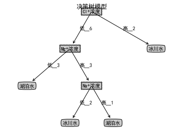

```python
#测试water.csv
#import DecisionTree_ID3
import matplotlib.pyplot as plt
from pylab import *
mpl.rcParams['font.sans-serif'] = ['SimHei']
#绘制决策树图
decisionNode = dict(boxstyle="sawtooth", fc="0.8")
leafNode = dict(boxstyle="round4", fc="0.8")
arrow_args = dict(arrowstyle="<-")

# 计算树的叶子节点数量
def getNumLeafs(myTree):
    numLeafs = 0
    firstStr = list(myTree.keys())[0]
    secondDict = myTree[firstStr]
    for key in secondDict.keys():
        if type(secondDict[key]).__name__ == 'dict':
            numLeafs += getNumLeafs(secondDict[key])
        else:
            numLeafs += 1
    return numLeafs

# 计算树的最大深度
def getTreeDepth(myTree):
    maxDepth = 0
    firstStr = list(myTree.keys())[0]
    secondDict = myTree[firstStr]
    for key in secondDict.keys():
        if type(secondDict[key]).__name__ == 'dict':
            thisDepth = 1 + getTreeDepth(secondDict[key])
        else:
            thisDepth = 1
        if thisDepth > maxDepth:
            maxDepth = thisDepth
    return maxDepth

# 画节点
def plotNode(nodeTxt, centerPt, parentPt, nodeType):
    createPlot.ax1.annotate(nodeTxt, xy=parentPt, xycoords='axes fraction', xytext=centerPt, textcoords='axes fraction',
                            va="center", ha="center", bbox=nodeType, arrowprops=arrow_args)
# 画箭头上的文字
def plotMidText(cntrPt, parentPt, txtString):
    lens = len(txtString)
    xMid = (parentPt[0] + cntrPt[0]) / 2.0 - lens * 0.002
    yMid = (parentPt[1] + cntrPt[1]) / 2.0
    createPlot.ax1.text(xMid, yMid, txtString)

def plotTree(myTree, parentPt, nodeTxt):
    numLeafs = getNumLeafs(myTree)
    depth = getTreeDepth(myTree)
    firstStr = list(myTree.keys())[0]
    cntrPt = (plotTree.x0ff + (1.0 + float(numLeafs)) / 2.0 / plotTree.totalW, plotTree.y0ff)
    plotMidText(cntrPt, parentPt, nodeTxt)
    plotNode(firstStr, cntrPt, parentPt, decisionNode)
    secondDict = myTree[firstStr]
    plotTree.y0ff = plotTree.y0ff - 1.0 / plotTree.totalD
    for key in secondDict.keys():
        if type(secondDict[key]).__name__ == 'dict':
            plotTree(secondDict[key], cntrPt, str(key))
        else:
            plotTree.x0ff = plotTree.x0ff + 1.0 / plotTree.totalW
            plotNode(secondDict[key], (plotTree.x0ff, plotTree.y0ff), cntrPt, leafNode)
            plotMidText((plotTree.x0ff, plotTree.y0ff), cntrPt, str(key))
    plotTree.y0ff = plotTree.y0ff + 1.0 / plotTree.totalD

def createPlot(inTree):
    fig = plt.figure(1, facecolor='white')
    fig.clf()
    axprops = dict(xticks=[], yticks=[])
    createPlot.ax1 = plt.subplot(111, frameon=False, **axprops)
    plotTree.totalW = float(getNumLeafs(inTree))
    plotTree.totalD = float(getTreeDepth(inTree))
    plotTree.x0ff = -0.5 / plotTree.totalW
    plotTree.y0ff = 1.0
    plotTree(inTree, (0.5, 1.0), '')
    plt.title("决策树模型")
    plt.show()

if __name__ == '__main__':
    import pandas as pd
    import numpy as np
    # 数据集
    df = pd.read_csv("water.csv")
    # 预测数据集
    dg = np.array([['低','高','高','低'],
                  ['高','高','低','高']])
    cols = df.columns.tolist()
    x = df[cols[:-1]].values
    y = df[cols[-1]].values

    li = DecisionTree_ID3()
    tree = li.fit(x,y)
    print(tree)
    print(li.predict(dg))

    #绘制决策树图
    decisionNode = dict(boxstyle="sawtooth", fc="0.8")
    leafNode = dict(boxstyle="round4", fc="0.8")
    arrow_args = dict(arrowstyle="<-")

    createPlot(tree)
```

### 1.4.2 C4.5 决策树

使用信息增益来选择特征的三个缺点：

1.容易偏向于优先选取取值种类较多的特征。

2.不能处理连续值特征。

3.容易过拟合。

针对以上三个缺点. C4.5 决策树给出了解决办法。 针对缺点1: C4.5 解决办法就是用信息增益比替代信息增益。 针对缺点2: C4.5的思路是先将连续的特征离散化。 针对缺点3: ID3决策树容易过拟合。 决策树的过拟合问题主要是由于树的分叉过细造成的， 决策树分叉过细会导致 最后生成的决策树模型对训练、集中的数据拟合得特别好，但是对新的预测集数据却 预测得很差，即模型的泛化能力不好。 C4.5 决策树引入了正则化系数进行初步的剪枝来缓解过拟合问题。 （具体的剪枝策略在下节的CART 决策树中会详细介绍）

除上述三点改进外， C4.5 决策树和ID3 决策树几乎一样。

```
0.34758988139079716
0.6100730651545314
0.3600730651545315
婚姻信息增益最大,g(婚姻)=0.610073
婚姻->未婚
特征属于同一类不用继续分叉
婚姻->已婚
0.9182958340544896
0.0
0.9182958340544896
房产信息增益最大,g(房产)=0.918296
房产->否
特征属于同一类不用继续分叉
房产->是
特征属于同一类不用继续分叉
婚姻->离婚
特征属于同一类不用继续分叉
决策树模型：
{'婚姻': {'未婚__3': '否', '已婚__3': {'房产': {'否__1': '是', '是__2': '否'}}, '离婚__2': '是'}}
预测结果：
['否' '是']
```

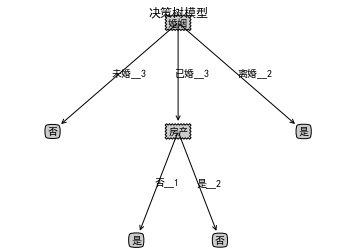

```python
#测试loan.csv
#import DecisionTree_ID3
import matplotlib.pyplot as plt
from pylab import *
mpl.rcParams['font.sans-serif'] = ['SimHei']
#绘制决策树图
decisionNode = dict(boxstyle="sawtooth", fc="0.8")
leafNode = dict(boxstyle="round4", fc="0.8")
arrow_args = dict(arrowstyle="<-")

# 计算树的叶子节点数量
def getNumLeafs(myTree):
    numLeafs = 0
    firstStr = list(myTree.keys())[0]
    secondDict = myTree[firstStr]
    for key in secondDict.keys():
        if type(secondDict[key]).__name__ == 'dict':
            numLeafs += getNumLeafs(secondDict[key])
        else:
            numLeafs += 1
    return numLeafs

# 计算树的最大深度
def getTreeDepth(myTree):
    maxDepth = 0
    firstStr = list(myTree.keys())[0]
    secondDict = myTree[firstStr]
    for key in secondDict.keys():
        if type(secondDict[key]).__name__ == 'dict':
            thisDepth = 1 + getTreeDepth(secondDict[key])
        else:
            thisDepth = 1
        if thisDepth > maxDepth:
            maxDepth = thisDepth
    return maxDepth

# 画节点
def plotNode(nodeTxt, centerPt, parentPt, nodeType):
    createPlot.ax1.annotate(nodeTxt, xy=parentPt, xycoords='axes fraction', xytext=centerPt, textcoords='axes fraction',
                            va="center", ha="center", bbox=nodeType, arrowprops=arrow_args)
# 画箭头上的文字
def plotMidText(cntrPt, parentPt, txtString):
    lens = len(txtString)
    xMid = (parentPt[0] + cntrPt[0]) / 2.0 - lens * 0.002
    yMid = (parentPt[1] + cntrPt[1]) / 2.0
    createPlot.ax1.text(xMid, yMid, txtString)

def plotTree(myTree, parentPt, nodeTxt):
    numLeafs = getNumLeafs(myTree)
    depth = getTreeDepth(myTree)
    firstStr = list(myTree.keys())[0]
    cntrPt = (plotTree.x0ff + (1.0 + float(numLeafs)) / 2.0 / plotTree.totalW, plotTree.y0ff)
    plotMidText(cntrPt, parentPt, nodeTxt)
    plotNode(firstStr, cntrPt, parentPt, decisionNode)
    secondDict = myTree[firstStr]
    plotTree.y0ff = plotTree.y0ff - 1.0 / plotTree.totalD
    for key in secondDict.keys():
        if type(secondDict[key]).__name__ == 'dict':
            plotTree(secondDict[key], cntrPt, str(key))
        else:
            plotTree.x0ff = plotTree.x0ff + 1.0 / plotTree.totalW
            plotNode(secondDict[key], (plotTree.x0ff, plotTree.y0ff), cntrPt, leafNode)
            plotMidText((plotTree.x0ff, plotTree.y0ff), cntrPt, str(key))
    plotTree.y0ff = plotTree.y0ff + 1.0 / plotTree.totalD

def createPlot(inTree):
    fig = plt.figure(1, facecolor='white')
    fig.clf()
    axprops = dict(xticks=[], yticks=[])
    createPlot.ax1 = plt.subplot(111, frameon=False, **axprops)
    plotTree.totalW = float(getNumLeafs(inTree))
    plotTree.totalD = float(getTreeDepth(inTree))
    plotTree.x0ff = -0.5 / plotTree.totalW
    plotTree.y0ff = 1.0
    plotTree(inTree, (0.5, 1.0), '')
    plt.title("决策树模型")
    plt.show()

if __name__ == '__main__':
    import pandas as pd
    import numpy as np
    # 数据集
    df = pd.read_csv("loan.csv")
    # 预测数据集
    dg = np.array([['是','未婚','高'],
                  ['否','已婚','高']])
    cols = df.columns.tolist()
    x = df[cols[:-1]].values
    y = df[cols[-1]].values

    li = DecisionTree_ID3()
    tree = li.fit(x,y)
    print(tree)
    print(li.predict(dg))

    #绘制决策树图
    decisionNode = dict(boxstyle="sawtooth", fc="0.8")
    leafNode = dict(boxstyle="round4", fc="0.8")
    arrow_args = dict(arrowstyle="<-")

    createPlot(tree)
```

### 1.4.3 CART 决策树--- 基尼系数最小准则

分类回归树(Classification And Regression Tree,CART ) 的模型，CART 既可以用于分类任务，又可以用于回归任务。

```python
问题1: 决策树和C4.5 决策树特征选择过程对数计算过于复杂。
问题2: 决策树和C4.5 决策树对特征划分过于迅速。
问题3: ID3 决策树和C4.5 决策树不能处理回归问题。
```

针对问题1: 当CART决策树用于分类任务时，采用基尼系数作为特征选择标准(基尼系数可达到与 熵值近似的效果，但是其计算要比基于熵的情况简捷很多〉。当CART决策树用于回归任务时， 采用平方误差最小化准则进行特征选择(和普通的回归问题是一样的)。这样可以减少大量的对数运算问题。

针对问题2: CART分类树与回归树采用二叉树来对每一个特征进行划分，具体过程如下。 当某一特征是离散值时， 比如|样本的某特征有{ 1 ，2 ，3 }三种可能取值， 那么CART 将分别计算按照{1}和{2 ，3 }、{2} 和{ 1 ，3} 、{ 3 }和{ 1 ， 2 } 三种情况划分时对应的基尼系数成平方误差， 然后从中选择基尼系数最小或平方误差最小的划分组合来进行二切分， 分叉成两个二叉子树。 当某一特征是连续值时: 比如样本中的年收入特征的取值可能有" 6，9, 10,12, 14, 16, 18, 20" 等多个值， 那么就先将这些值按从大到小的顺序排列好，然后依次取每两个相邻值 的中位数作为划分点(假设上面年收入特征在样本中一共有n个，则相当于要j进行n-1次划分)，然后比较这n-1次划分对应的基尼系数或者平方误差，选择基尼系数或平方误差最小的划分来生成二叉子树。 使得CART 可以对同-特征进行多次利用。

针对问题3: 回归问题的结果取值是很多个连续值，因此不能像分类问题一样采用信息增益 或基尼系数等特征选择标准。 直接使用均方误差就行， 即计算每一次特征划分后的结果与实际结果值之间的均方误差， 采用均方误差最小的划分作为最优划分。

解诀了特征选择问题， 还剩结果处理问题，所有决策树采用的结果处理方式都是对每一个叶子节点里面包含的所有样本的类别进行统计， 然后选择样本类别占多数者对应的类别标签作为该叶子节点的类别标签。换到回归问题，其实只诺稍作变化即可， 比如每个叶子节点对应的结果值就取该叶子节点中所有样本点标签值的均值。

[figure not shown]

### 分类效果评价

```python
对于一般分类问题，有训练误差、泛化误差、准确率、错误率等指标.
对于常见的二分类问题，样本只有两种分类结果，将其定义为正例与反例。
那么在进行分类时，对于一个样本，可能出现的分类情况共有四种:
  --样本为正例，被分类为正例，称为真正类(TP)
  --样本为正例，被分类为反例，称为假反类(FN)
  --样本为反例，被分类为正例，称为假正类(FP)
  --样本为反例，被分类为反例，称为真反类(TN)
```

[figure not shown]

差别2: 决策树结果输出处理方式不同。

CART 回归树的输出结果不是类别，因而它把最终各个叶子中所有样本对应结果值的均值或者中位数当作预测的结果输出(注: 最后生成的决策树的 各个叶子节点中一般仍含有多个样本) 。

除上述两点外， CART 分类树和CART 回归树的生成过程和预测过程基本一致。

CART 回归树的过程 输入: 训练集T = {(x1，y1)， (x2 ,y2), ..., (xm, ym)} 。 输出:回归树f(x) 。

### 1.4.4 决策树的剪枝

决策树算法很容易对训练集过拟合， 从而导致泛化能力较差。为了解决这个问题， 一般需要对CART 决策树进行剪枝。

剪枝有先剪枝和后剪枝两种， 先剪枝是在生成决策树的过程中就采取一定措施来限制某些不必要的子树的生成。 后剪枝就是先使用训练集中的大部分数据去尽可能生成一棵最大的树，然后从决策树的底端开始不断剪枝，直到形成一棵只有一个根节点的子树凡，得到一个剪枝后的子树序列{T0，T1， ...， TK } ， 最后利用余下的数据进行交叉验证，选出其中的最优子树。

## 2. 集成学习--Ensemble learning

集成学习(Ensemble learning)是机器学习中近年来的一大热门领域。其中的集成方法是用多种学习方法的组合来获取比原方法更优的结果 使用于组合的算法是弱学习算法，即分类正确率仅比随机猜测略高的学习算法，但是组合之后的效果仍可能高于强学习算法，即集成之后的算法准确率和效率都很高 在集成学习方法中，其泛化能力比单个学习方法强。

[figure not shown]

### 装袋法

Bagging(Bootstrap Aggregating)算法通过对训练样本有放回的抽取，由此产生多个训练集，并在每一个训练集的子集上训练一个分类器，最终结果是由多个分类结果投票而产生的。Bagging算法的整个过程如下图所示。

[figure not shown]

### 提升法

Boosting算法通过顺序地给训练集中的数据项重新加权创造不同的基础学习器。其核心思想是重复应用一个基础学习器来修改训练数据集。

[figure not shown]

### 梯度提升决策树--GBDT

梯度提升决策树算法是利用梯度下降的思想，使用损失函数的负梯度在当前模型的值，作为提升树中残差的近似值，以此来拟合回归决策树。梯度提升决策树的算法过程如下： 初始化决策树，估计一个使损失函数最小化的常数构建一个只有根节点的树。

不断提升迭代：

---计算当前模型中损失函数的负梯度值，作为残差的估计值；

---估计回归树中叶子节点的区域，拟合残差的近似值；

---利用线性搜索估计叶子节点区域的值，使损失函数极小化；

---更新决策树。

经过若干轮的提升法迭代过程之后，输出最终的模型

### 随机森林算法

随机森林(Random Forest,RF)算法是一种基于Bagging的集成学习方法，可以用来做分类、回归等问题。这里主要介绍随机森林在分类问题中的应用。随机森林是由一系列的决策树组成，它通过自助(Bootstrap)重采样技术，从原始训练样本中有放回地重复随机抽取m个样本，生成新的训练样本集合，然后根据自助样本集合生成k个分类树组成的随机森林，新数据的分类结果按分类树投票多少形成的分数而定。其实质是对决策树算法的一种改进，将多个决策树合并在一起，每一棵树的建立依赖于一个独立抽取的样本，森林中的每一棵树具有相同的分布，分类误差取决于每一棵树的分类能力和它们之间的相关性。特征选择采用随机的方法分裂每一个节点，然后比较不同情况下产生的误差。能够检测到的内在估计误差、分类能力和相关性决定特征的数目。单棵树的分类能力可能很小，但在随机产生大量的决策树后，一个测试样品可以通过统计每一棵树的分类结果，从而选择最有可能的分类。

随机森林算法流程：

随机森林算法是通过训练多个决策树，生成模型，然后综合利用多个决策树进行分类。随机森林算法只需要两个参数：构建的决策树的个数n，在决策树的每个节点进行分裂时需要考虑的输入的特征的个数k，通常k可以取log2(n)，其中n表示的是元数据集中的个数。对于单棵决策树的构建，可以分为如下步骤：

(1)假设训练样本的个数为m，则对于每一个决策树的输入样本的个数都为m，且这个m个样本是通过从训练集中有放回地随机抽样得到的。

(2)假设训练样本特征的个数为n，对于每一棵决策树的样本特征是从该n个特征中随机挑选k个，然后从k个输入特征中选择最好的进行分裂。

(3)每棵树都一直这样分裂下去，直到该节点的所有训练样例都属于同一类。在决策树分裂过程中不需要剪枝。